# MONITORING PERSONAL ACTIVITIES

Andreia Vieira

18/08/2020

## Introduction

Evaluation of an individual’s data collected at 5-minute intervals during the day, including the number of steps performed. Data were collected in 2012, during the months of October and November.

#### Data characteristic

Dataset: Activity Monitoring Data (.CSV) (https://d396qusza40orc.cloudfront.net/repdata%2Fdata%2Factivity.zip) [52K] Total: 17,568 observations

#### Variables:

steps: Number of steps taking in a 5-minute interval (missing values are coded as NA) date: The date on which the measurement was taken in YYYY-MM-DD format interval: Identifier for the 5-minute interval in which measurement was taken

### Data analysis

#### 1) Loading and/or preprocessing the data

```r
 library(ggplot2)
 library(plyr)


temp <- tempfile()
download.file("https://d396qusza40orc.cloudfront.net/repdata%2Fdata%2Factivity.zip",temp, mode="wb")
unzip(temp, "activity.csv" )
Activity_Monitoring <- read.csv("activity.csv", sep=",", header=TRUE)
str(Activity_Monitoring)
```

```
## 'data.frame':    17568 obs. of  3 variables:
##  $ steps   : int  NA NA NA NA NA NA NA NA NA NA ...
##  $ date    : chr  "2012-10-01" "2012-10-01" "2012-10-01" "2012-10-01" ...
##  $ interval: int  0 5 10 15 20 25 30 35 40 45 ...
```

###### Data clean and format

```r
data_clean_activity<-Activity_Monitoring[!is.na(Activity_Monitoring$steps),] #15264 obs. of  3 variables
data_clean_activity <-data_clean_activity [order(data_clean_activity$interval),] # order
data_clean_activity$date<- as.POSIXct(data_clean_activity$date, format="%Y-%m-%d")
str(data_clean_activity)
```

```
## 'data.frame':    15264 obs. of  3 variables:
##  $ steps   : int  0 0 47 0 0 0 0 34 0 0 ...
##  $ date    : POSIXct, format: "2012-10-02" "2012-10-03" ...
##  $ interval: int  0 0 0 0 0 0 0 0 0 0 ...
```

#### 2) Histogram of the total number of steps taken each day

###### Sum steps

```r
sum_steps <- aggregate(data_clean_activity$steps ~ data_clean_activity$date, FUN=sum)
colnames(sum_steps)<- c("date", "steps")
sum_steps <-sum_steps [order(sum_steps$steps),] # order
head(sum_steps,10)
```

```
##          date steps
## 39 2012-11-15    41
## 1  2012-10-02   126
## 23 2012-10-25  2492
## 35 2012-11-08  3219
## 44 2012-11-20  4472
## 27 2012-10-29  5018
## 40 2012-11-16  5441
## 24 2012-10-26  6778
## 53 2012-11-29  7047
## 38 2012-11-13  7336
```

```r
hist(sum_steps$steps, col="darkblue", border="black", xlab="Steps", main="Total Steps per Day")
```

[output not shown]

#### 3) Average and median - number of steps taken each Day

###### Average obtain sum steps daily: mean and median

```r
mean_steps <- aggregate(data_clean_activity$steps ~ data_clean_activity$date, FUN=mean)
colnames(mean_steps)<- c("date", "steps")
#mean_steps # Average each day

median_steps <- aggregate(data_clean_activity$steps ~ data_clean_activity$date, FUN=median)
colnames(median_steps)<- c("date", "steps")
#median_steps  # median each day


# Average obtain sum steps daily

mean_total_steps <- mean(sum_steps$steps)
median_total_steps <- median(sum_steps$steps)
mean_total_steps
```

```
## [1] 10766.19
```

```r
median_total_steps
```

```
## [1] 10765
```

```r
# mean 10766.19 and median 10765
```

###### Average steps to all interval

```r
mean_total_steps <- mean(data_clean_activity $steps)
mean_total_steps
```

```
## [1] 37.3826
```

#### 4) Time series plot of the average number of steps taken (daily)

```r
mean_steps_day <- aggregate(data_clean_activity$steps ~ data_clean_activity$date, FUN=mean)
colnames(mean_steps_day)<- c("date", "steps")
head(mean_steps_day,10)
```

```
##          date    steps
## 1  2012-10-02  0.43750
## 2  2012-10-03 39.41667
## 3  2012-10-04 42.06944
## 4  2012-10-05 46.15972
## 5  2012-10-06 53.54167
## 6  2012-10-07 38.24653
## 7  2012-10-09 44.48264
## 8  2012-10-10 34.37500
## 9  2012-10-11 35.77778
## 10 2012-10-12 60.35417
```

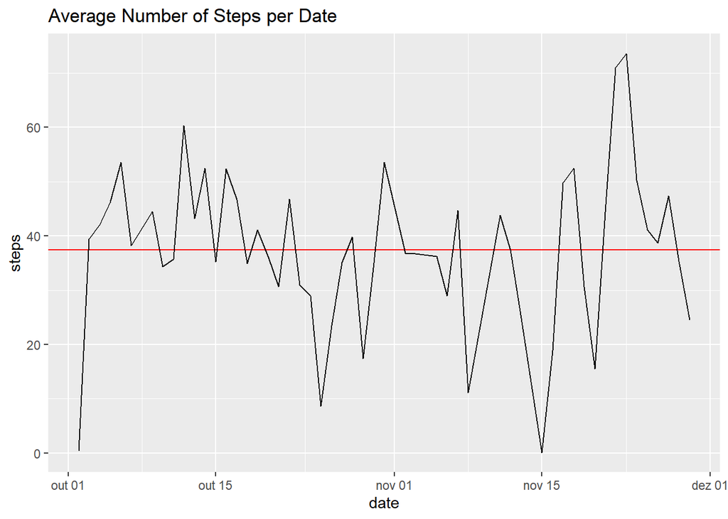

```r
# Plot Time series  x=date

ggplot(mean_steps, aes(x = date, y = steps) , xlab="Date" , ylab="Mean Steps") + geom_hline(yintercept=mean(mean_steps_day$steps ), col="red")+ geom_line() + ggtitle("Average Number of Steps per Date")
```

#### 5) The 5-minute interval that, on average, contains the maximum number of steps

###### First Average Number of Steps per Interval. After interval that, on average, contains the maximum number of steps.

```r
mean_steps_interval_5min <- aggregate(data_clean_activity$steps ~ data_clean_activity$interval, FUN=mean)
colnames(mean_steps_interval_5min)<- c("interval", "steps")
head(mean_steps_interval_5min,10)
```

```
##    interval     steps
## 1         0 1.7169811
## 2         5 0.3396226
## 3        10 0.1320755
## 4        15 0.1509434
## 5        20 0.0754717
## 6        25 2.0943396
## 7        30 0.5283019
## 8        35 0.8679245
## 9        40 0.0000000
## 10       45 1.4716981
```

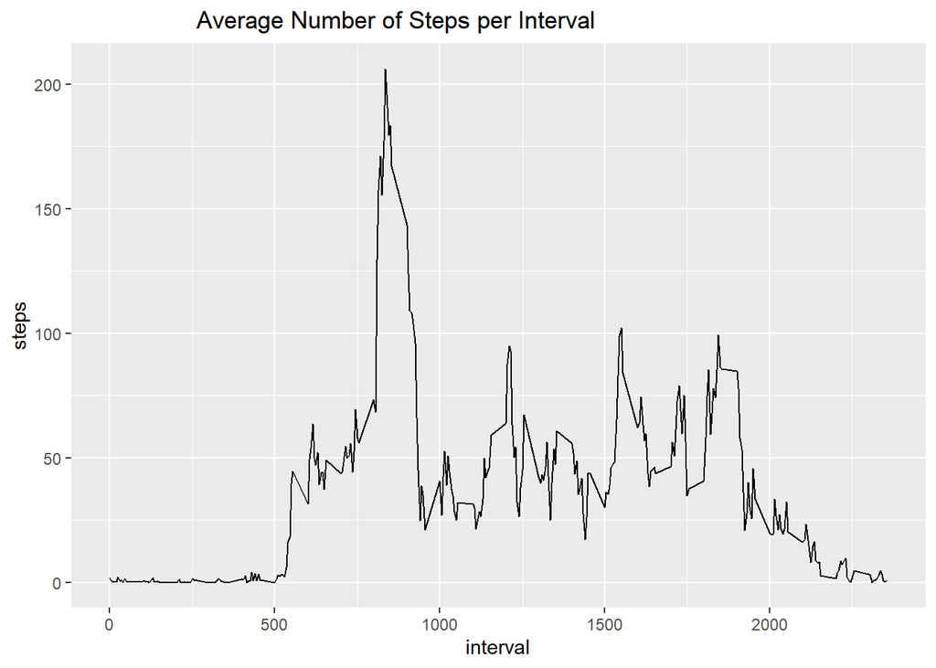

```r
# Plot Time series  x= 5-minute interval

ggplot(mean_steps_interval_5min, aes(x = interval, y = steps) , xlab="Interval" , ylab="Mean Steps") + geom_line() + ggtitle("                  Average Number of Steps per Interval")
```

###### Maximum number of steps

```r
maxSteps_interval_order<-mean_steps_interval_5min[order(-mean_steps_interval_5min $steps, mean_steps_interval_5min $interval),]

#maximum

head(maxSteps_interval_order, n=1)
```

```
##     interval    steps
## 104      835 206.1698
```

```r
#All interval
head(maxSteps_interval_order,10) # all
```

```
##     interval    steps
## 104      835 206.1698
## 105      840 195.9245
## 107      850 183.3962
## 106      845 179.5660
## 103      830 177.3019
## 101      820 171.1509
## 108      855 167.0189
## 100      815 157.5283
## 102      825 155.3962
## 109      900 143.4528
```

```r
# The interval that contains the maximum number of steps is 835.  In this interval, the average of steps was 206.1698
```

#### 6) Code to describe and show a strategy for imputing missing data

###### The mean can distort the results due to the amount of outliers - 2304 records. So, the outliers will test by mean and mediana. However, the substitution by the media presented a behavior similar to the clean data.

###### Calculation of median

```r
replace_median <- aggregate(data_clean_activity $steps ~ data_clean_activity$interval, FUN=median)
colnames(replace_median)<- c("interval", "steps")
head(replace_median,10)
```

```
##    interval steps
## 1         0     0
## 2         5     0
## 3        10     0
## 4        15     0
## 5        20     0
## 6        25     0
## 7        30     0
## 8        35     0
## 9        40     0
## 10       45     0
```

###### Calculation of mean

```r
#Calculation of mean
replace_mean <- aggregate(data_clean_activity $steps ~ data_clean_activity $interval, FUN=mean)
colnames(replace_mean)<- c("interval", "steps")
head(replace_mean,10)
```

```
##    interval     steps
## 1         0 1.7169811
## 2         5 0.3396226
## 3        10 0.1320755
## 4        15 0.1509434
## 5        20 0.0754717
## 6        25 2.0943396
## 7        30 0.5283019
## 8        35 0.8679245
## 9        40 0.0000000
## 10       45 1.4716981
```

###### Filter NA

```r
data_for_clean <- Activity_Monitoring [is.na(Activity_Monitoring$steps),] # all outliers (read csv - line 47)
data_for_clean$date<- as.POSIXct(data_for_clean$date, format="%Y-%m-%d")
data_for_clean<- data_for_clean[order(data_for_clean$interval) ,]

str(data_for_clean)
```

```
## 'data.frame':    2304 obs. of  3 variables:
##  $ steps   : int  NA NA NA NA NA NA NA NA NA NA ...
##  $ date    : POSIXct, format: "2012-10-01" "2012-10-08" ...
##  $ interval: int  0 0 0 0 0 0 0 0 5 5 ...
```

###### Replace NA by median

```r
data_clean_median<-data_for_clean
m=nrow(data_clean_median) #  registros for clean
n=nrow(replace_median) # median each intervals
for(i in 1:m)  #1 ate nrow(data_for_clean)
       for(j in 1:n)  #1 ate nrow(replace_median)
                 if (data_clean_median$interval[i]==replace_median$interval[j]) {
                     data_clean_median$steps [i]= replace_median$steps[j]
                     break
                }
data_replace_median<-data_clean_median
str(data_replace_median)
```

```
## 'data.frame':    2304 obs. of  3 variables:
##  $ steps   : int  0 0 0 0 0 0 0 0 0 0 ...
##  $ date    : POSIXct, format: "2012-10-01" "2012-10-08" ...
##  $ interval: int  0 0 0 0 0 0 0 0 5 5 ...
```

###### Replace NA by mean

```r
data_clean_mean<-data_for_clean
m=nrow(data_clean_mean) #  registros for clean
n=nrow(replace_mean) # median each intervals
for(i in 1:m)  #1 ate nrow(data_for_clean_mean)
       for(j in 1:n)  #1 ate nrow(replace_median)
                 if (data_clean_mean$interval[i]==replace_mean$interval[j]) {
                     data_clean_mean$steps [i]= replace_mean$steps[j]
                     break
                }
data_replace_mean<-data_clean_mean
str(data_replace_mean)
```

```
## 'data.frame':    2304 obs. of  3 variables:
##  $ steps   : num  1.72 1.72 1.72 1.72 1.72 ...
##  $ date    : POSIXct, format: "2012-10-01" "2012-10-08" ...
##  $ interval: int  0 0 0 0 0 0 0 0 5 5 ...
```

##### 7) Histograma com atributos NA substuídos with media, before too test median

###### Replace by median

```r
data_clean_and_NA_replace_median<-rbind(data_clean_activity, data_replace_median)
sum_steps_after_replace<-data_clean_and_NA_replace_median
sum_steps_after_replace <- aggregate(sum_steps_after_replace$steps ~ sum_steps_after_replace$date, FUN=sum)
colnames(sum_steps_after_replace)<- c("interval", "steps")
sum_steps_after_replace <-sum_steps_after_replace[order(sum_steps_after_replace$steps),] # order
head(sum_steps_after_replace,10)
```

```
##      interval steps
## 46 2012-11-15    41
## 2  2012-10-02   126
## 1  2012-10-01  1141
## 8  2012-10-08  1141
## 32 2012-11-01  1141
## 35 2012-11-04  1141
## 40 2012-11-09  1141
## 41 2012-11-10  1141
## 45 2012-11-14  1141
## 61 2012-11-30  1141
```

```r
# histogram initial - line 73
hist(sum_steps$steps, col="darkblue", border="black", xlab="Steps", main="Total Steps per Day")
```

[output not shown]

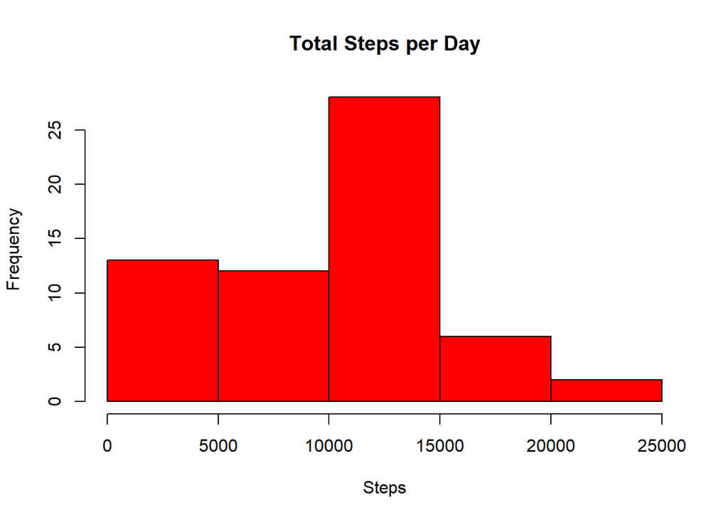

```r
#mean BEST RESULT
hist(sum_steps_after_replace$steps, col="red", border="black", xlab="Steps", main="Total Steps per Day")
```

###### Replace by mean (best result)

```r
data_clean_and_NA_replace_mean<-rbind(data_clean_activity, data_replace_mean)
sum_steps_after_replace<-data_clean_and_NA_replace_mean
sum_steps_after_replace <- aggregate(sum_steps_after_replace$steps ~ sum_steps_after_replace$date, FUN=sum)
colnames(sum_steps_after_replace)<- c("interval", "steps")
sum_steps_after_replace <-sum_steps_after_replace[order(sum_steps_after_replace$steps),] # order
head(sum_steps_after_replace,10)
```

```
##      interval steps
## 46 2012-11-15    41
## 2  2012-10-02   126
## 25 2012-10-25  2492
## 39 2012-11-08  3219
## 51 2012-11-20  4472
## 29 2012-10-29  5018
## 47 2012-11-16  5441
## 26 2012-10-26  6778
## 60 2012-11-29  7047
## 44 2012-11-13  7336
```

```r
# histogram initial - line 73
hist(sum_steps$steps, col="darkblue", border="black", xlab="Steps", main="Total Steps per Day")
```

[output not shown]

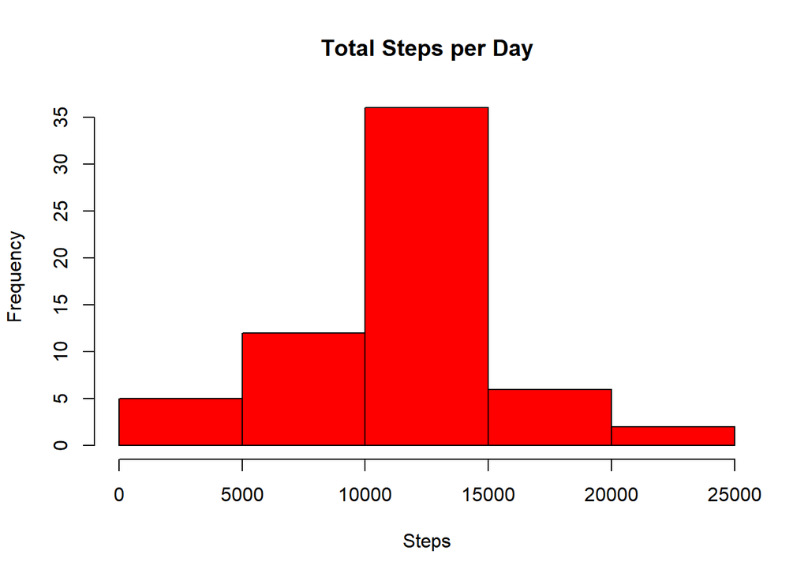

```r
#mean BEST RESULT
hist(sum_steps_after_replace$steps, col="red", border="black", xlab="Steps", main="Total Steps per Day")
```

###### category: weekend or weekday: NA replaced media

```r
category_day<-data_clean_and_NA_replace_mean # data with NA replaced media

category_day$date <- as.Date(category_day$date)
category_day$days=weekdays(as.Date(category_day$date))


#replace weekend and weekday
category_day$days<- ifelse(category_day$days == "sabado" | category_day$days == "domingo", "weekend", "weekday")
head(category_day,10)
```

```
##      steps       date interval    days
## 289      0 2012-10-02        0 weekday
## 577      0 2012-10-03        0 weekday
## 865     47 2012-10-04        0 weekday
## 1153     0 2012-10-05        0 weekday
## 1441     0 2012-10-06        0 weekday
## 1729     0 2012-10-07        0 weekend
## 2305     0 2012-10-09        0 weekday
## 2593    34 2012-10-10        0 weekday
## 2881     0 2012-10-11        0 weekday
## 3169     0 2012-10-12        0 weekday
```

```r
mean_category_day <- aggregate(category_day$steps ~ category_day$interval + category_day$days, FUN=mean, data=category_day)
##mean_category_day<- as.POSIXct(mean_category_day$date, format="%Y-%m-%d")
colnames(mean_category_day)<- c("interval","days","steps")
head(mean_category_day,10)
```

```
##    interval    days      steps
## 1         0 weekday 1.94375222
## 2         5 weekday 0.38447846
## 3        10 weekday 0.14951940
## 4        15 weekday 0.17087932
## 5        20 weekday 0.08543966
## 6        25 weekday 1.38981844
## 7        30 weekday 0.59807761
## 8        35 weekday 0.98255607
## 9        40 weekday 0.00000000
## 10       45 weekday 1.66607334
```

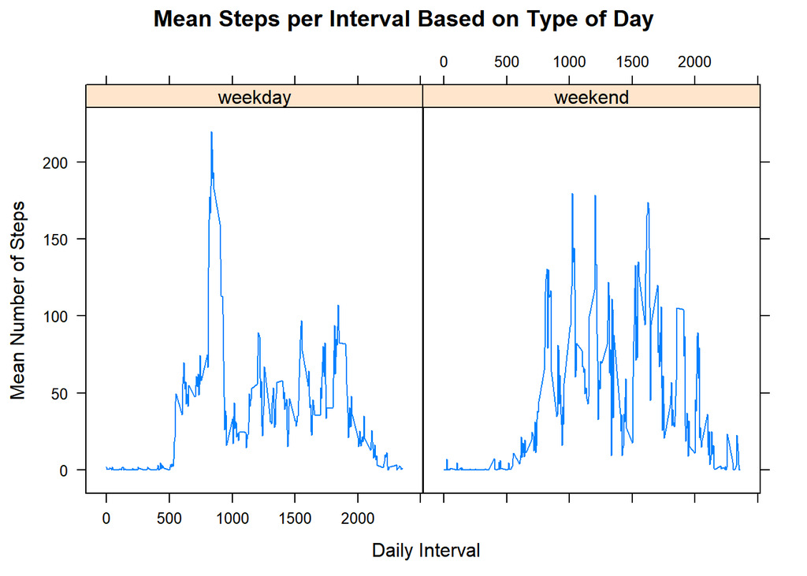

```r
library(lattice)
xyplot(mean_category_day$steps ~ mean_category_day$interval | mean_category_day$days, data=mean_category_day, type="l",    main="Mean Steps per Interval Based on Type of Day",   ylab="Mean Number of Steps", xlab=" Daily Interval")
```

###### category: weekend or weekday: delete dataset with NA

```r
category_day<-data_clean_activity # data without NA

category_day$date <- as.Date(category_day$date)
category_day$days=weekdays(as.Date(category_day$date))


#replace weekend and weekday
category_day$days<- ifelse(category_day$days == "sabado" | category_day$days == "domingo", "weekend", "weekday")
head(category_day,10)
```

```
##      steps       date interval    days
## 289      0 2012-10-02        0 weekday
## 577      0 2012-10-03        0 weekday
## 865     47 2012-10-04        0 weekday
## 1153     0 2012-10-05        0 weekday
## 1441     0 2012-10-06        0 weekday
## 1729     0 2012-10-07        0 weekend
## 2305     0 2012-10-09        0 weekday
## 2593    34 2012-10-10        0 weekday
## 2881     0 2012-10-11        0 weekday
## 3169     0 2012-10-12        0 weekday
```

```r
mean_category_day <- aggregate(category_day$steps ~ category_day$interval + category_day$days, FUN=mean, data=category_day)
##mean_category_day<- as.POSIXct(mean_category_day$date, format="%Y-%m-%d")
colnames(mean_category_day)<- c("interval","days","steps")
head(mean_category_day,10)
```

```
##    interval    days      steps
## 1         0 weekday 1.97826087
## 2         5 weekday 0.39130435
## 3        10 weekday 0.15217391
## 4        15 weekday 0.17391304
## 5        20 weekday 0.08695652
## 6        25 weekday 1.28260870
## 7        30 weekday 0.60869565
## 8        35 weekday 1.00000000
## 9        40 weekday 0.00000000
## 10       45 weekday 1.69565217
```

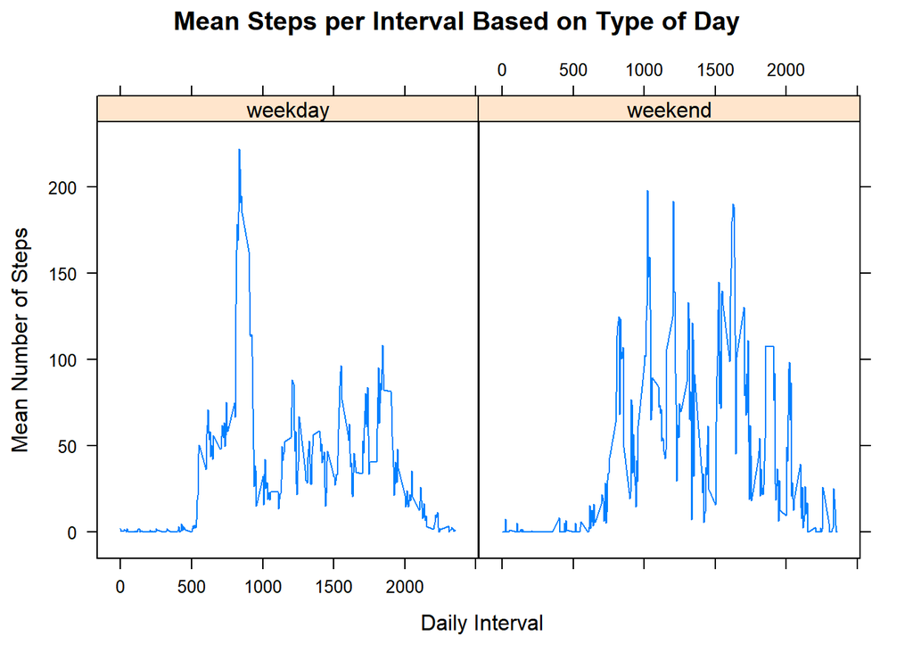

```r
library(lattice)
xyplot(mean_category_day$steps ~ mean_category_day$interval | mean_category_day$days, data=mean_category_day, type="l",    main="Mean Steps per Interval Based on Type of Day",   ylab="Mean Number of Steps", xlab=" Daily Interval")
```